# The forecaster’s toolbox: fable

2025-03-17

Reading: Ch5.1

| Type | why? |
| --- | --- |
| Short-term forecasts | needed for the scheduling of personnel, production and transportation. As part of the scheduling process, forecasts of demand are often also required. |
| Medium-term forecasts | are needed to determine future resource requirements, in order to purchase raw materials, hire personnel, or buy machinery and equipment. |
| Long-term forecasts | used in strategic planning. Such decisions must take account of market opportunities, environmental factors and internal resources. |

- When we decompose a time series into components, we usually combine the trend and cycle into a single trend-cycle component (often just called the trend for simplicity).
- Thus we can think of a time series as comprising three components:
  - a trend-cycle component,
  - a seasonal component, and
  - a remainder component (containing anything else in the time series).
- For some time series (e.g., those that are observed at least daily), there can be more than one seasonal component, corresponding to the different seasonal periods.

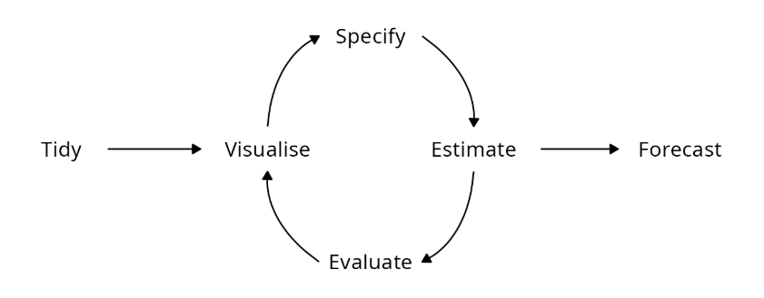

The process of producing forecasts for time series data

# Overview

## 1. Prep Data

- Convert the data into tsibble and use tidyverse to perform any data transformation

```r
gdppc <- global_economy |>
  mutate(GDP_per_capita = GDP / Population)
```

## 2. EDA

- Always plot data

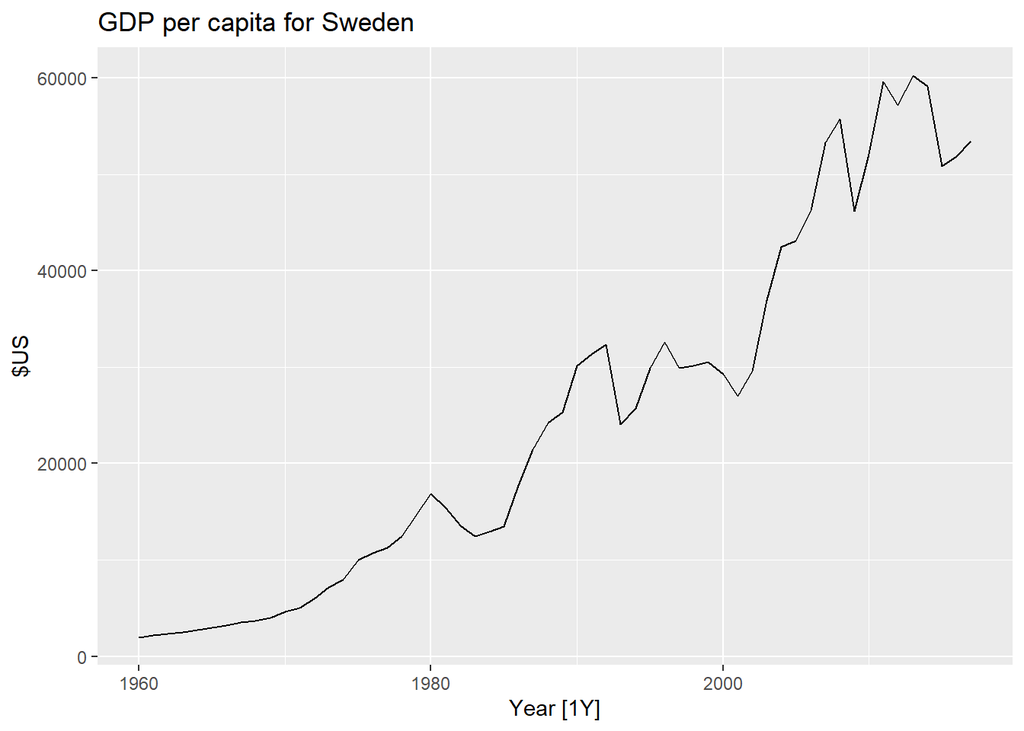

```r
gdppc |>
  filter(Country == "Sweden") |>
  autoplot(GDP_per_capita) +
  labs(y = "$US", title = "GDP per capita for Sweden")
```

## 3. Model

- Models in fable are specified using model functions, which each use a formula `(y ~ x)` interface.

### Train the model

```r
fit <- gdppc |>
  model(trend_model = TSLM(GDP_per_capita ~ trend()))
fit
```

```
## # A mable: 263 x 2
## # Key:     Country [263]
##    Country             trend_model
##    <fct>                   <model>
##  1 Afghanistan              <TSLM>
##  2 Albania                  <TSLM>
##  3 Algeria                  <TSLM>
##  4 American Samoa           <TSLM>
##  5 Andorra                  <TSLM>
##  6 Angola                   <TSLM>
##  7 Antigua and Barbuda      <TSLM>
##  8 Arab World               <TSLM>
##  9 Argentina                <TSLM>
## 10 Armenia                  <TSLM>
## # ℹ 253 more rows
```

## 4. Forecasts

```r
fit |> forecast(h = "3 years")
```

```
## # A fable: 789 x 5 [1Y]
## # Key:     Country, .model [263]
##    Country        .model       Year
##    <fct>          <chr>       <dbl>
##  1 Afghanistan    trend_model  2018
##  2 Afghanistan    trend_model  2019
##  3 Afghanistan    trend_model  2020
##  4 Albania        trend_model  2018
##  5 Albania        trend_model  2019
##  6 Albania        trend_model  2020
##  7 Algeria        trend_model  2018
##  8 Algeria        trend_model  2019
##  9 Algeria        trend_model  2020
## 10 American Samoa trend_model  2018
## # ℹ 779 more rows
## # ℹ 2 more variables: GDP_per_capita <dist>, .mean <dbl>
```

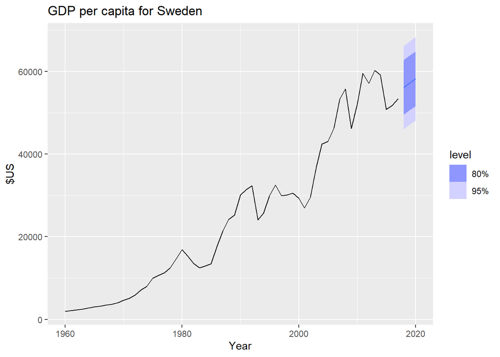

```r
fit |>
  forecast(h = "3 years") |>
  filter(Country == "Sweden") |>
  autoplot(gdppc) +
  labs(y = "$US", title = "GDP per capita for Sweden")
```

# TLSM

## Simple linear regressoin

$$y = ax + b$$

```r
head(us_change)
```

```
## # A tsibble: 6 x 6 [1Q]
##   Quarter Consumption Income Production Savings Unemployment
##     <qtr>       <dbl>  <dbl>      <dbl>   <dbl>        <dbl>
## 1 1970 Q1       0.619  1.04      -2.45     5.30        0.9
## 2 1970 Q2       0.452  1.23      -0.551    7.79        0.5
## 3 1970 Q3       0.873  1.59      -0.359    7.40        0.5
## 4 1970 Q4      -0.272 -0.240     -2.19     1.17        0.700
## 5 1971 Q1       1.90   1.98       1.91     3.54       -0.100
## 6 1971 Q2       0.915  1.45       0.902    5.87       -0.100
```

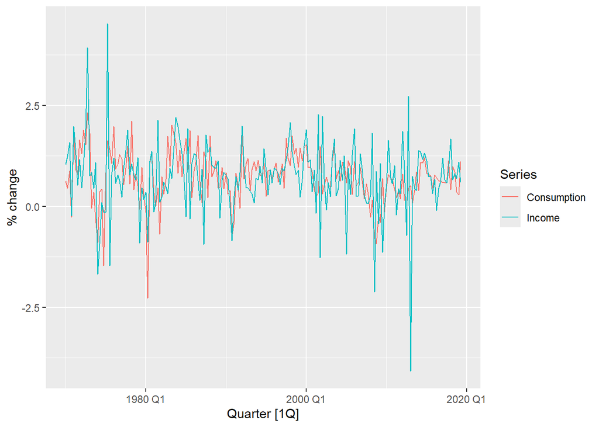

```r
us_change |>
  pivot_longer(c(Consumption, Income), names_to="Series") |>
  autoplot(value) +
  labs(y = "% change")
```

```r
m0 <- lm(Consumption ~ Income, data = us_change)
summary(m0)
```

```
##
## Call:
## lm(formula = Consumption ~ Income, data = us_change)
##
## Residuals:
##      Min       1Q   Median       3Q      Max
## -2.58236 -0.27777  0.01862  0.32330  1.42229
##
## Coefficients:
##             Estimate Std. Error t value Pr(>|t|)
## (Intercept)  0.54454    0.05403  10.079  < 2e-16 ***
## Income       0.27183    0.04673   5.817  2.4e-08 ***
## ---
## Signif. codes:  0 '***' 0.001 '**' 0.01 '*' 0.05 '.' 0.1 ' ' 1
##
## Residual standard error: 0.5905 on 196 degrees of freedom
## Multiple R-squared:  0.1472, Adjusted R-squared:  0.1429
## F-statistic: 33.84 on 1 and 196 DF,  p-value: 2.402e-08
```

```r
us_change |>
  model(TSLM(Consumption ~ Income)) |>
  report()
```

```
## Series: Consumption
## Model: TSLM
##
## Residuals:
##      Min       1Q   Median       3Q      Max
## -2.58236 -0.27777  0.01862  0.32330  1.42229
##
## Coefficients:
##             Estimate Std. Error t value Pr(>|t|)
## (Intercept)  0.54454    0.05403  10.079  < 2e-16 ***
## Income       0.27183    0.04673   5.817  2.4e-08 ***
## ---
## Signif. codes:  0 '***' 0.001 '**' 0.01 '*' 0.05 '.' 0.1 ' ' 1
##
## Residual standard error: 0.5905 on 196 degrees of freedom
## Multiple R-squared: 0.1472,  Adjusted R-squared: 0.1429
## F-statistic: 33.84 on 1 and 196 DF, p-value: 2.4022e-08
```

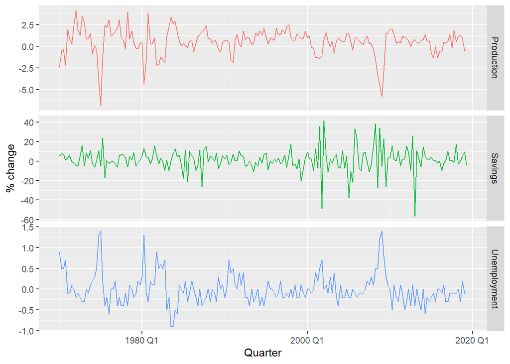

```r
us_change |>
  select(-Consumption, -Income) |>
  pivot_longer(-Quarter) |>
  ggplot(aes(Quarter, value, colour = name)) +
  geom_line() +
  facet_grid(name ~ ., scales = "free_y") +
  guides(colour = "none") +
  labs(y="% change")
```

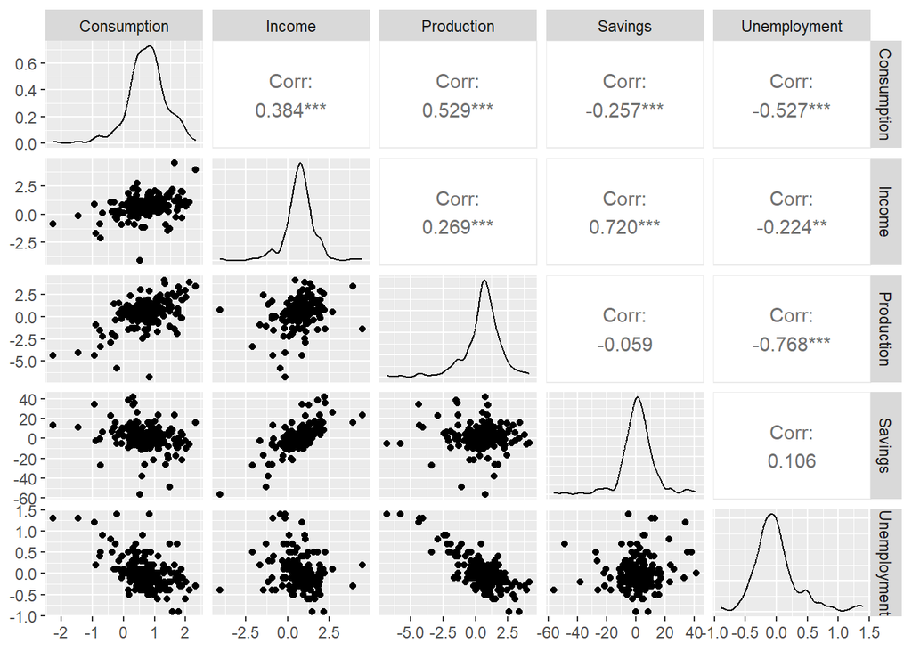

```r
us_change |>
  GGally::ggpairs(columns = 2:6)
```

## assumptions

- Functional form is correct.
- Related to $\epsilon$,
  - $E[\epsilon] = 0$
  - They are not autocorrelated; otherwise the forecasts will be inefficient, as there is more information in the data that can be exploited.
  - Not correlated with predictors.
    - otherwise there would be more information that should be included in the systematic part of the model.
  - Normally distributed
- Another important assumption in the linear regression model is that each predictor $x$ is not a random variable.
  - If we were performing a controlled experiment in a laboratory, we could control the values of each $x$ (so they would not be random) and observe the resulting values of $y$.
  - With observational data (including most data in business and economics), it is not possible to control the value of $x$, we simply observe it. Hence we make this an assumption.

## MLR

- `trend()` and `season()` are not standard functions; they are `special` functions that work within the `TSLM()` model.

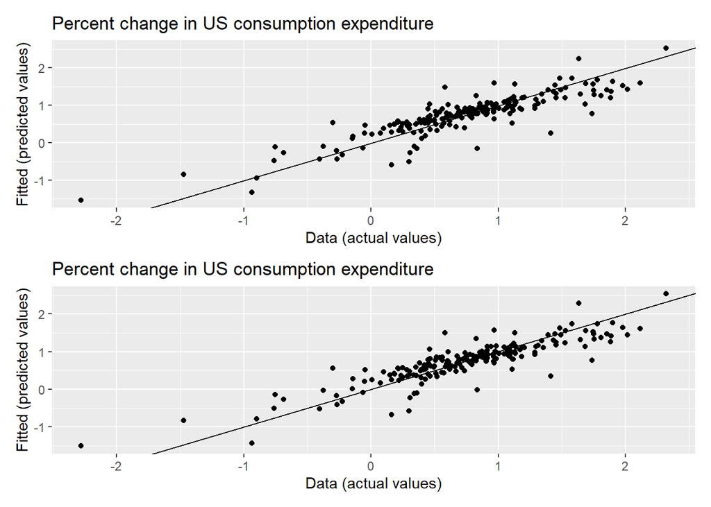

```r
fit_consMR <- us_change |>
  model(tslm = TSLM(Consumption ~ Income + Production +
                                    Unemployment + Savings))



fit <- us_change |>
  model(tslm = TSLM(Consumption ~ trend() + season()+
                      Unemployment + Savings +
                      Income + Production ))

p1 <- augment(fit_consMR) |>
  ggplot(aes(x = Consumption, y = .fitted)) +
  geom_point() +
  labs(
    y = "Fitted (predicted values)",
    x = "Data (actual values)",
    title = "Percent change in US consumption expenditure"
  ) +
  geom_abline(intercept = 0, slope = 1)


p2 <- augment(fit) |>
  ggplot(aes(x = Consumption, y = .fitted)) +
  geom_point() +
  labs(
    y = "Fitted (predicted values)",
    x = "Data (actual values)",
    title = "Percent change in US consumption expenditure"
  ) +
  geom_abline(intercept = 0, slope = 1)


p1/p2
```

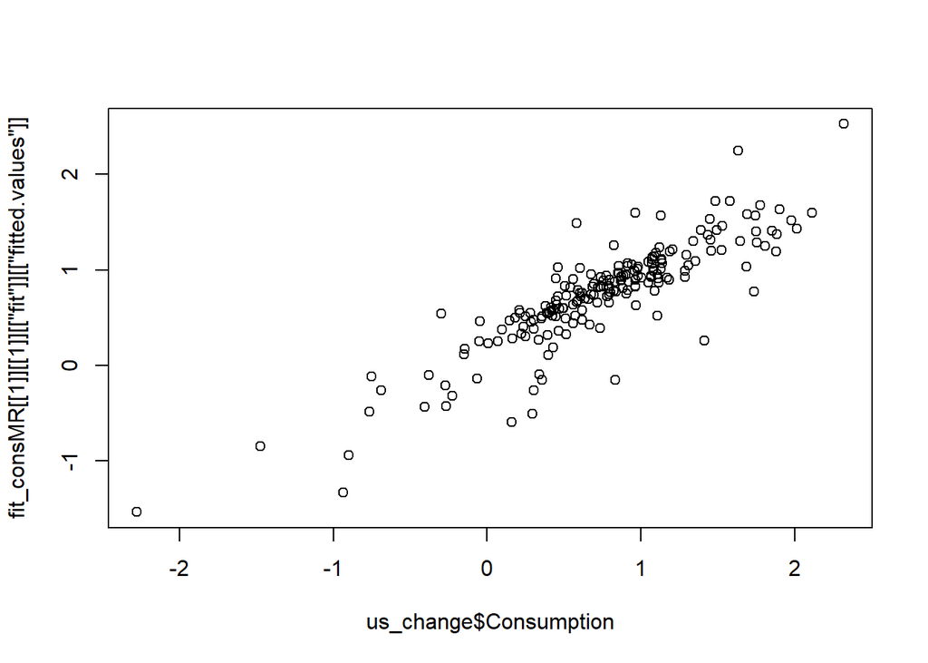

```r
plot(us_change$Consumption, fit_consMR[[1]][[1]][["fit"]][["fitted.values"]])
```

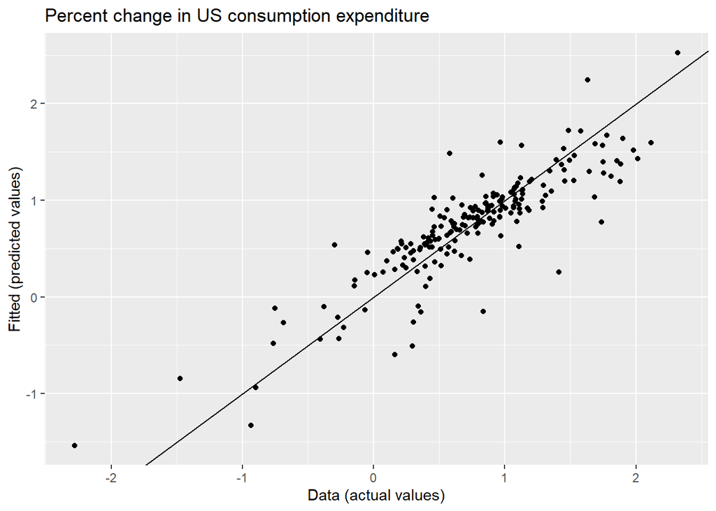

```r
augment(fit_consMR) |>
  ggplot(aes(x = Consumption, y = .fitted)) +
  geom_point() +
  labs(
    y = "Fitted (predicted values)",
    x = "Data (actual values)",
    title = "Percent change in US consumption expenditure"
  ) +
  geom_abline(intercept = 0, slope = 1)
```

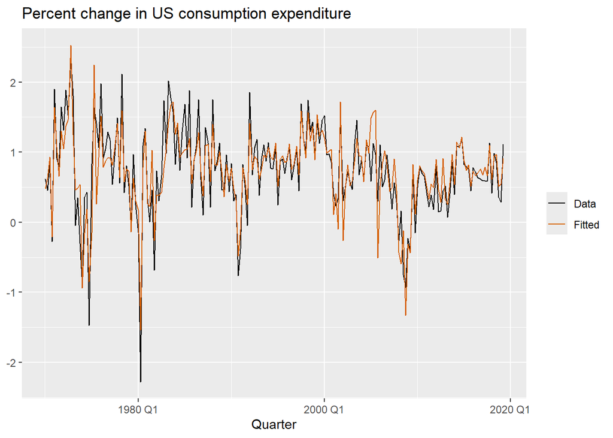

```r
augment(fit_consMR) |>
  ggplot(aes(x = Quarter)) +
  geom_line(aes(y = Consumption, colour = "Data")) +
  geom_line(aes(y = .fitted, colour = "Fitted")) +
  labs(y = NULL,
    title = "Percent change in US consumption expenditure"
  ) +
  scale_colour_manual(values=c(Data="black",Fitted="#D55E00")) +
  guides(colour = guide_legend(title = NULL))
```

## Evaluate the fit

### evaluate the residual

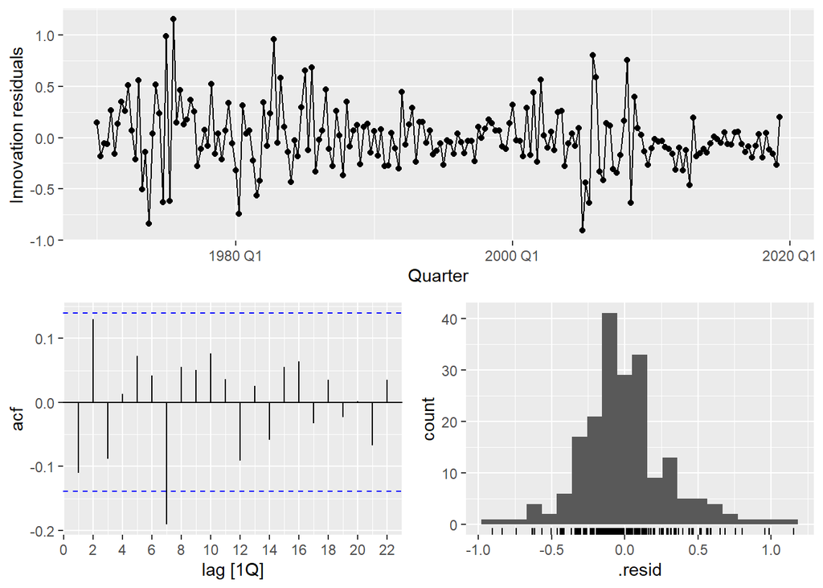

```r
fit_consMR |> gg_tsresiduals()
```

```r
augment(fit_consMR) |>
  features(.innov, ljung_box, lag = 10)
```

```
## # A tibble: 1 × 3
##   .model lb_stat lb_pvalue
##   <chr>    <dbl>     <dbl>
## 1 tslm      18.9    0.0420
```

- The time plot shows some changing variation over time, but is otherwise relatively unremarkable. This heteroscedasticity will potentially make the prediction interval coverage inaccurate.
- The histogram shows that the residuals seem to be slightly skewed, which may also affect the coverage probability of the prediction intervals.
- The autocorrelation plot shows a significant spike at lag 7, and a significant Ljung-Box test at the 5% level. However, the autocorrelation is not particularly large, and at lag 7 it is unlikely to have any noticeable impact on the forecasts or the prediction intervals.

### TSLM special functions

- `fourier()`
- The K argument to fourier() specifies how many pairs of sin and cos terms to include. The maximum allowed is $K = \frac{m}{2}$ where `m`is the seasonal period. Because we have used the maximum here, the results are identical to those obtained when using seasonal dummy variables.
- If only the first two Fourier terms are used ($x_{1,t},x_{2,t}$),the seasonal pattern will follow a simple sine wave. A regression model containing Fourier terms is often called a `harmonic regression` because the successive Fourier terms represent harmonics of the first two Fourier terms.

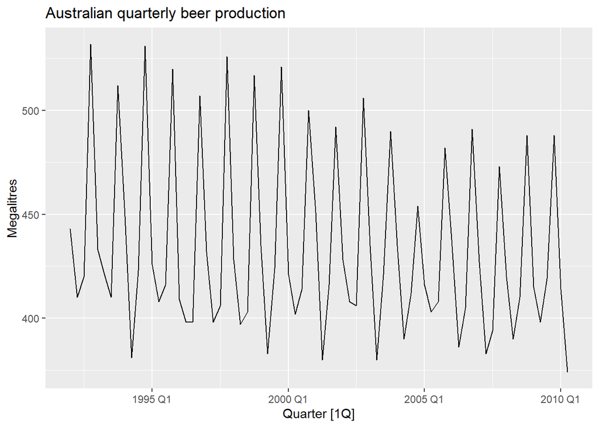

```r
recent_production <- aus_production |>
  filter(year(Quarter) >= 1992)
recent_production |>
  autoplot(Beer) +
  labs(y = "Megalitres",
       title = "Australian quarterly beer production")
```

```r
fit_beer <- recent_production |>
  model(TSLM(Beer ~ trend() + season()))
report(fit_beer)
```

```
## Series: Beer
## Model: TSLM
##
## Residuals:
##      Min       1Q   Median       3Q      Max
## -42.9029  -7.5995  -0.4594   7.9908  21.7895
##
## Coefficients:
##                Estimate Std. Error t value Pr(>|t|)
## (Intercept)   441.80044    3.73353 118.333  < 2e-16 ***
## trend()        -0.34027    0.06657  -5.111 2.73e-06 ***
## season()year2 -34.65973    3.96832  -8.734 9.10e-13 ***
## season()year3 -17.82164    4.02249  -4.430 3.45e-05 ***
## season()year4  72.79641    4.02305  18.095  < 2e-16 ***
## ---
## Signif. codes:  0 '***' 0.001 '**' 0.01 '*' 0.05 '.' 0.1 ' ' 1
##
## Residual standard error: 12.23 on 69 degrees of freedom
## Multiple R-squared: 0.9243,  Adjusted R-squared: 0.9199
## F-statistic: 210.7 on 4 and 69 DF, p-value: < 2.22e-16
```

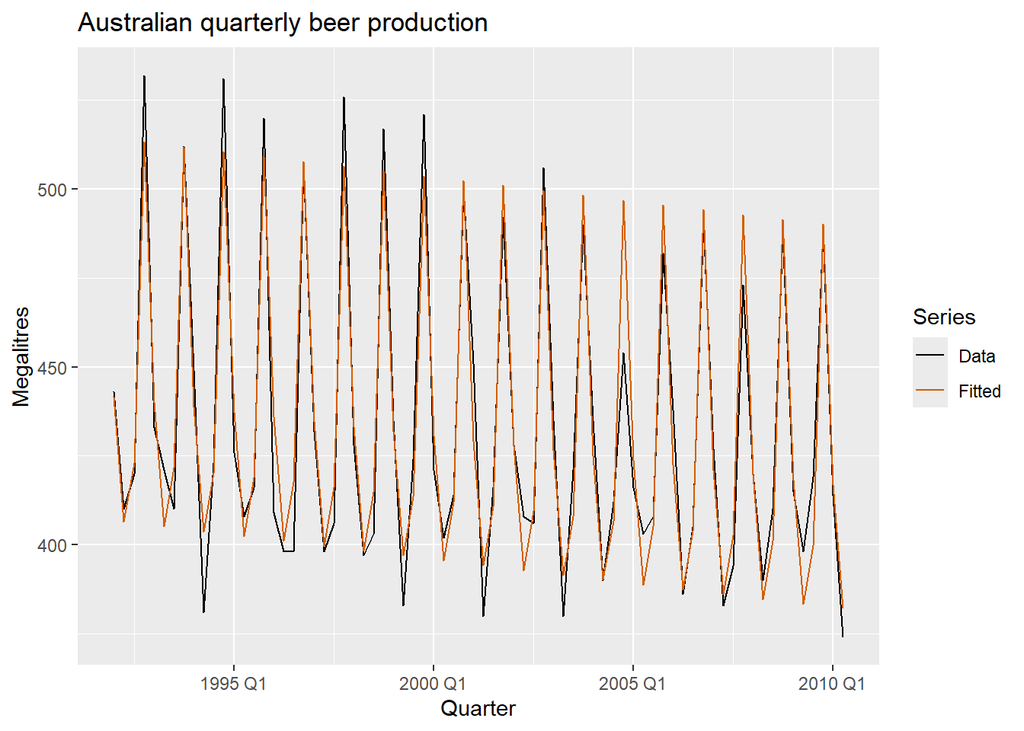

```r
augment(fit_beer) |>
  ggplot(aes(x = Quarter)) +
  geom_line(aes(y = Beer, colour = "Data")) +
  geom_line(aes(y = .fitted, colour = "Fitted")) +
  scale_colour_manual(
    values = c(Data = "black", Fitted = "#D55E00")
  ) +
  labs(y = "Megalitres",
       title = "Australian quarterly beer production") +
  guides(colour = guide_legend(title = "Series"))
```

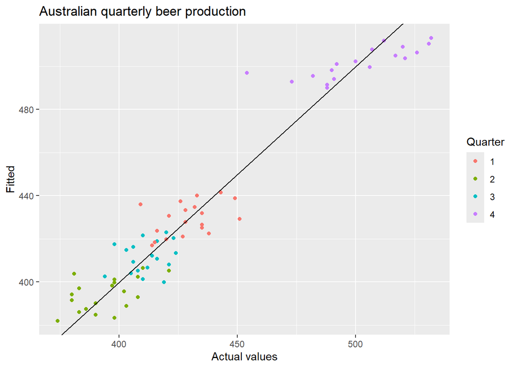

```r
augment(fit_beer) |>
  ggplot(aes(x = Beer, y = .fitted,
             colour = factor(quarter(Quarter)))) +
  geom_point() +
  labs(y = "Fitted", x = "Actual values",
       title = "Australian quarterly beer production") +
  geom_abline(intercept = 0, slope = 1) +
  guides(colour = guide_legend(title = "Quarter"))
```

```r
fourier_beer <- recent_production |>
  model(TSLM(Beer ~ trend() + fourier(K = 2)))
report(fourier_beer)
```

```
## Series: Beer
## Model: TSLM
##
## Residuals:
##      Min       1Q   Median       3Q      Max
## -42.9029  -7.5995  -0.4594   7.9908  21.7895
##
## Coefficients:
##                     Estimate Std. Error t value Pr(>|t|)
## (Intercept)        446.87920    2.87321 155.533  < 2e-16 ***
## trend()             -0.34027    0.06657  -5.111 2.73e-06 ***
## fourier(K = 2)C1_4   8.91082    2.01125   4.430 3.45e-05 ***
## fourier(K = 2)S1_4 -53.72807    2.01125 -26.714  < 2e-16 ***
## fourier(K = 2)C2_4 -13.98958    1.42256  -9.834 9.26e-15 ***
## ---
## Signif. codes:  0 '***' 0.001 '**' 0.01 '*' 0.05 '.' 0.1 ' ' 1
##
## Residual standard error: 12.23 on 69 degrees of freedom
## Multiple R-squared: 0.9243,  Adjusted R-squared: 0.9199
## F-statistic: 210.7 on 4 and 69 DF, p-value: < 2.22e-16
```